# Capstone Code with Notes

Max Davis

10/7/2019

Load libraries that I will use for exploring the data, and for cleaning it.

```r
library(readr)
library(dplyr)
```

```r
library(tidyr)
library(ggplot2)
library(data.table)
```

Read data for full Haute Born Wind farm from 2017 to 2020, and the data description file or metadata using the fread() function with data.table = FALSE:

```r
haute_all_2017_2020 <- fread("la-haute-borne-data-2017-2020.csv", data.table = FALSE)
data_description <- fread("data_description.csv")
```

Make tibble of data:

```r
haute <- tbl_df(haute_all_2017_2020)
metadata <- tbl_df(data_description)
```

Make a list of old names and one of replacement names from metadata:

```r
old <- metadata[,"Variable_name"]
new <- metadata[, "Variable_long_name"]
```

Create a function to replace old names with a corresponding longer name on the new names list:

```r
fast_clean <- function(df, x) {colnames(df) <- gsub (old[[c(1, x)]], new[[c(1, x)]], colnames(df)) ; df}
```

Apply the fast_clean function first to two column names that would create distortions in a while loop:

```r
haute<- fast_clean(haute, 20)
haute<- fast_clean(haute, 27)
```

Use a while loop to take the old part of each column name and replace it by increments, skipping variable 20 and 27, which I have already done in the previous code chunk:

```r
n <- 1
while(n < 20) {haute <- fast_clean(df = haute, x = n)
  n <- (n + 1)
  }
n <- 21
while(n < 27) {haute <- fast_clean(df = haute, x = n)
  n <- (n + 1)
  }
n <- 28
while(n <= 34) {haute <- fast_clean(df = haute, x = n)
  n <- (n + 1)
  }
```

Separate date and time in the datetime column:

```r
haute <- separate(haute, "Date_time", c("date", "time"), sep = "T", remove = TRUE, convert = FALSE, extra = "warn", fill = "warn")
```

Make Date into date format:

```r
haute$date <- as.Date(haute$date, "%Y-%m-%d")
```

The code is ready for some meaningful exploration. See “Exploratory Plots.rmd” .

**Feature Engineering and Machine Learning

In the exploration phase of the project, there was a lot that jumped out as interesting. But I decided to focus on instances of turbines not functioning as intended. This will require first some feature engineering. I will create a new feature “down” that displays a 1 if the wind speed is above 5 m/s but average active power is below 50 kW. In other words, a feature that tells me when a turbine “should” be producing power, but is not.

```r
down <- ifelse(haute$Wind_speed_avg > 5 & haute$Active_power_avg < 50, 1, 0)
summary(down)
```

```
##    Min. 1st Qu.  Median    Mean 3rd Qu.    Max.    NA's
##  0.0000  0.0000  0.0000  0.0115  0.0000  1.0000    1658
```

```r
haute$down <- as.factor(down)
class(haute$down)
```

```
## [1] "factor"
```

Here I want to create a subset that includes all of my features, including min and max values, and the new feature down but remove turbine ID, date, time. Since I wont be doing any time series analysis. I will also remove all wind and power related features, since they are baked into the feature “down”.

```r
down <- haute$down
haute_clean <- select(haute, -c(1,2,3))
haute_clean <- haute_clean %>%
                  select(-contains("Wind")) %>%
                  select(-contains("Power"))
```

I will view the number of missing values in each column.

```r
missing.values <- haute_clean %>%
  gather(key = "key", value = "val") %>%
  mutate(is.missing = is.na(val)) %>%
  group_by(key, is.missing) %>%
  summarise(num.missing = n()) %>%
  filter(is.missing==T) %>%
  select(-is.missing) %>%
  arrange(desc(num.missing))
missing.values
```

```
## # A tibble: 97 x 2
## # Groups:   key [97]
##    key                         num.missing
##    <chr>                             <int>
##  1 Nacelle_angle_corrected_max      217588
##  2 Nacelle_angle_corrected_min      217588
##  3 Nacelle_angle_corrected_std      217588
##  4 Nacelle_angle_corrected_avg      183657
##  5 Vane_position_avg                140456
##  6 Vane_position_max                140456
##  7 Vane_position_min                140456
##  8 Vane_position_std                140456
##  9 Vane_position1_avg                79081
## 10 Vane_position1_max                79081
## # … with 87 more rows
```

```r
haute_complete <- haute_clean %>%
                drop_na(down)
```

I will remove the columns from the dataset with the most NAs (where over a third of rows are missing values). This could be a place for further experimentation later on, but for now, I will remove them.

```r
haute_complete <- haute_clean
haute_complete <- haute_complete %>%
                  select(-contains("Vane_position")) %>%
                  select(-contains("Nacelle_angle_corrected"))
```

Now haute_complete is the working dataset. I will check the balance. This will be important as the model used on the data will be logistic regression. This will also be considered the baseline prediction for negative cases.

```r
table(haute_complete$down)
```

```
##
##      0      1
## 213451   2479
```

```r
down_table <- table(haute_complete$down)
down_table
```

```
##
##      0      1
## 213451   2479
```

```r
down_table[1]/(down_table[1] + down_table[2])
```

```
##         0
## 0.9885194
```

A plot of the full dataset with “down” mapped to color will highlight the cases I am interested in predicting.

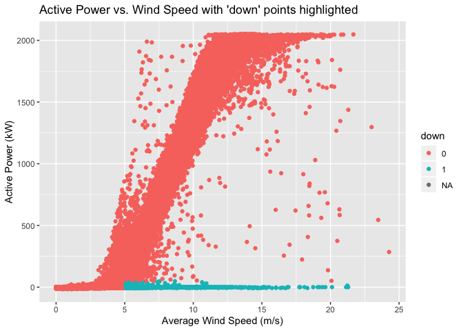

```r
ggplot(haute, aes(x = Wind_speed_avg, y = Active_power_avg))+
  geom_point(aes(color = down)) +
  labs(x = "Average Wind Speed (m/s)", y = "Active Power (kW)") +
  ggtitle("Active Power vs. Wind Speed with 'down' points highlighted")
```

**Machine Learning

```r
library(caret)
library(DMwR)
set.seed(2555)
smote_haute <- SMOTE(down ~ ., data = as.data.frame(haute_complete))
smoted_haute <- table(smote_haute$down)
smoted_haute
```

```
##
##    0    1
## 9846 7437
```

```r
smoted_haute[2]/smoted_haute[1]
```

```
##         1
## 0.7553321
```

```r
smote_haute <- tbl_df(smote_haute)
```

Now I want to check out the missing values after using SMOTE:

```r
missing.values <- smote_haute %>%
  gather(key = "key", value = "val") %>%
  mutate(is.missing = is.na(val)) %>%
  group_by(key, is.missing) %>%
  summarise(num.missing = n()) %>%
  filter(is.missing==T) %>%
  select(-is.missing) %>%
  arrange(desc(num.missing))
missing.values
```

```
## # A tibble: 81 x 2
## # Groups:   key [81]
##    key                 num.missing
##    <chr>                     <int>
##  1 Torque_avg                 1500
##  2 Torque_max                 1500
##  3 Torque_min                 1500
##  4 Torque_std                 1500
##  5 Rotor_speed_avg            1115
##  6 Rotor_speed_max            1115
##  7 Rotor_speed_min            1115
##  8 Rotor_speed_std            1115
##  9 Generator_speed_avg         618
## 10 Generator_speed_max         618
## # … with 71 more rows
```

There are 70 missing values in the “down” column. I will remove these rows.

```r
smote_haute <- smote_haute %>%
                drop_na(down)
```

Now I want to create a logistic regression model with the clean and balanced dataset, in which there are no missing values for “down”. Additionally, and this is absolutely key to getting a result. I must use na.omit on the dataset before splitting it. I will split the balanced data into a train and test set with split.seed from caTools.

```r
library(caTools)
set.seed(2555)
smote_haute <- na.omit(smote_haute)
split <- sample.split(smote_haute$down, SplitRatio = .65)
train <- subset(smote_haute, split == TRUE)
test <- subset(smote_haute, split == FALSE)
table(train$down)
```

```
##
##    0    1
## 6304 3914
```

```r
table(test$down)
```

```
##
##    0    1
## 3394 2107
```

I will create a logistic regression model to predict down, based on the training data.

```r
trainlogistic <- glm(down ~ ., data = train, family = binomial)
summary(trainlogistic)
```

```
##
## Call:
## glm(formula = down ~ ., family = binomial, data = train)
##
## Deviance Residuals:
##    Min      1Q  Median      3Q     Max
##  -8.49    0.00    0.00    0.00    8.49
##
## Coefficients:
##                                       Estimate Std. Error    z value
## (Intercept)                         -4.731e+15  2.603e+07 -181726402
## Pitch_angle_avg                      4.955e+13  3.093e+05  160228929
## Pitch_angle_min                     -9.446e+12  2.860e+05  -33024643
## Pitch_angle_max                      2.992e+12  3.201e+05    9347167
## Pitch_angle_std                      1.467e+13  8.896e+05   16493526
## Hub_temperature_avg                  3.250e+13  3.406e+06    9541964
## Hub_temperature_min                  9.837e+13  3.354e+06   29327933
## Hub_temperature_max                 -1.587e+14  3.105e+06  -51114334
## Hub_temperature_std                 -2.967e+14  8.770e+06  -33833736
## Generator_converter_speed_avg       -3.412e+13  4.899e+05  -69649452
## Generator_converter_speed_min        1.181e+13  5.104e+05   23131964
## Generator_converter_speed_max       -1.807e+12  2.731e+05   -6615583
## Generator_converter_speed_std       -2.864e+13  7.632e+05  -37526600
## Converter_torque_avg                -9.468e+11  2.627e+04  -36037114
## Converter_torque_min                -2.080e+11  7.878e+03  -26402343
## Converter_torque_max                 6.068e+11  2.851e+04   21280657
## Converter_torque_std                 2.623e+12  4.598e+04   57049203
## Generator_speed_avg                  3.211e+13  6.217e+05   51654203
## Generator_speed_min                  1.344e+13  5.164e+05   26027744
## Generator_speed_max                  1.236e+13  3.133e+05   39440487
## Generator_speed_std                 -2.051e+13  9.609e+05  -21347751
## Generator_bearing_1_temperature_avg  1.341e+14  2.484e+06   53958622
## Generator_bearing_1_temperature_min -8.742e+13  8.955e+05  -97617959
## Generator_bearing_1_temperature_max  3.711e+12  2.546e+06    1457611
## Generator_bearing_1_temperature_std -2.209e+14  7.463e+06  -29599386
## Generator_bearing_2_temperature_avg -4.302e+14  5.289e+06  -81336184
## Generator_bearing_2_temperature_min  3.071e+14  1.568e+06  195832741
## Generator_bearing_2_temperature_max  2.775e+13  4.504e+06    6161587
## Generator_bearing_2_temperature_std  2.302e+14  1.129e+07   20395607
## Generator_stator_temperature_avg     3.829e+13  1.128e+06   33953750
```

[output cut: 128 more lines]

```
## Rotor_bearing_temperature_std         <2e-16 ***
## Torque_avg                            <2e-16 ***
## Torque_min                            <2e-16 ***
## Torque_max                            <2e-16 ***
## Torque_std                            <2e-16 ***
## ---
## Signif. codes:  0 '***' 0.001 '**' 0.01 '*' 0.05 '.' 0.1 ' ' 1
##
## (Dispersion parameter for binomial family taken to be 1)
##
##     Null deviance: 13601  on 10217  degrees of freedom
## Residual deviance: 22635  on 10137  degrees of freedom
## AIC: 22797
##
## Number of Fisher Scoring iterations: 25
```

Now I will predict in the test set which turbines are down, using the logistic regression model I have just made

```r
predictTest <- predict(trainlogistic, type = "response", newdata = test)
table(test$down)
```

```
##
##    0    1
## 3394 2107
```

```r
table(test$down, predictTest > .5)
```

```
##
##     FALSE TRUE
##   0  3306   88
##   1   112 1995
```

I will visualize the results in a confusion matrix:

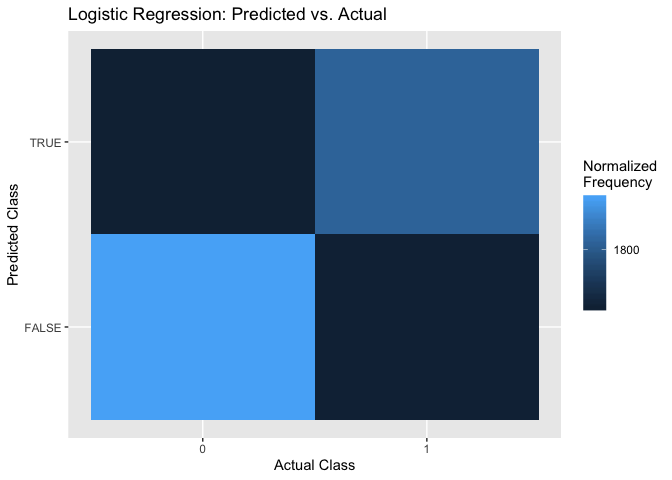

```r
input.matrix <- data.matrix(table(test$down, predictTest > .5))

colnames(input.matrix) = c(FALSE, TRUE)
rownames(input.matrix) = c(0, 1)

glmconfusion <- as.data.frame(as.table(input.matrix))
b <- c(0, 1800, 3500)
plot <- ggplot(glmconfusion)
plot +
  geom_tile(aes(x=Var1, y=Var2, fill=Freq)) +
        labs(fill = "Normalized\nFrequency") +
        scale_x_discrete(name="Actual Class") +
        scale_y_discrete(name="Predicted Class") +
        scale_fill_gradient(breaks=b, labels = format(b)) +
        ggtitle("Logistic Regression: Predicted vs. Actual")
```

I will measure the performance of this model overall by measuring the area under the ROC curve and plotting it.

```r
library(ROCR)
ROCRpred <- prediction(predictTest, test$down)
as.numeric(performance(ROCRpred, "auc")@y.values)
```

```
## [1] 0.9604579
```

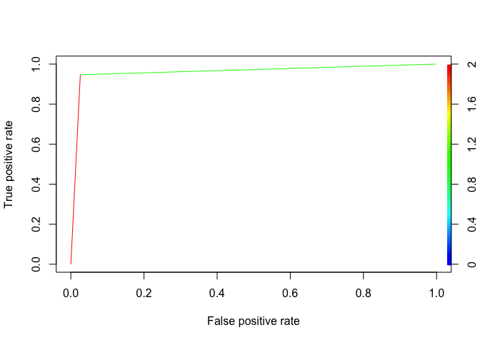

```r
perf <- performance(ROCRpred,"tpr","fpr")
plot(perf,colorize=TRUE)
```

Logistic regression produces some result, though it is problematic (I will talk about this in the report). I will try cross validation.

```r
ctrl <- trainControl(method = "repeatedcv", number = 10, savePredictions = TRUE)

mod_fit <- train(down ~ .,  data = train, method="glm", family="binomial",
                 trControl = ctrl, tuneLength = 5)
predCV <- predict(mod_fit, newdata = test)

summary(predCV)
```

```
##    0    1
## 3418 2083
```

And visualize the confusion matrix for this as well.

```r
table(predCV, test$down)
```

```
##
## predCV    0    1
##      0 3306  112
##      1   88 1995
```

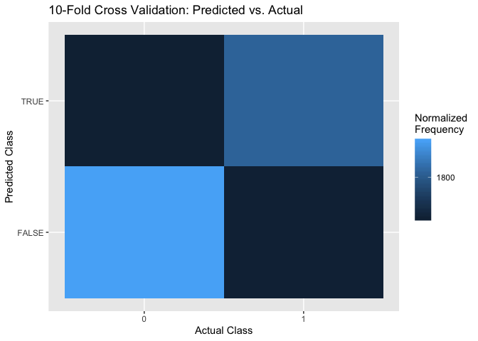

```r
confusion2 <- confusionMatrix(data = predCV, test$down)

input.matrix2 <- data.matrix(table(test$down, predictTest > .5))


colnames(input.matrix2) = c(FALSE, TRUE)
rownames(input.matrix2) = c(0, 1)

confusion2 <- as.data.frame(as.table(input.matrix))
b <- c(0, 1800, 3500)
plot2 <- ggplot(confusion2)
plot2 +
  geom_tile(aes(x=Var1, y=Var2, fill=Freq)) +
        labs(fill = "Normalized\nFrequency") +
        scale_x_discrete(name="Actual Class") +
        scale_y_discrete(name="Predicted Class") +
        scale_fill_gradient(breaks=b, labels = format(b)) +
        ggtitle("10-Fold Cross Validation: Predicted vs. Actual")
```

Accuracy for the GLM prediction

```r
as.numeric(performance(ROCRpred, "auc")@y.values)
```

```
## [1] 0.9604579
```

```r
table(test$down, predictTest > .5)
```

```
##
##     FALSE TRUE
##   0  3306   88
##   1   112 1995
```

Accuracy for the cross validation.

```r
confusionMatrix(predCV, test$down)
```

```
## Confusion Matrix and Statistics
##
##           Reference
## Prediction    0    1
##          0 3306  112
##          1   88 1995
##
##                Accuracy : 0.9636
##                  95% CI : (0.9584, 0.9684)
##     No Information Rate : 0.617
##     P-Value [Acc > NIR] : <2e-16
##
##                   Kappa : 0.9229
##
##  Mcnemar's Test P-Value : 0.1039
##
##             Sensitivity : 0.9741
##             Specificity : 0.9468
##          Pos Pred Value : 0.9672
##          Neg Pred Value : 0.9578
##              Prevalence : 0.6170
##          Detection Rate : 0.6010
##    Detection Prevalence : 0.6213
##       Balanced Accuracy : 0.9605
##
##        'Positive' Class : 0
##
```

Ultimately, this problem may not be the best one to exemplify machine learning. While it is apparent that the data allows us to predict the case of a turbine being down, with high accuracy, I have a hunch that this is because a wind turbine’s system of sensors is designed to do just that. In other words, every system monitored by sensors has a close relationship to either wind speed or power. The temperatures of various components, the vane positions, the pitch angles, all of these componenets are designed in relationship to the wind and the power distribution. A more nuanced approach to prediction with this data would probably include some kind of time series analysis, in which certain features in the moments or days before a condition of “down” or similar is registered may be used to predict the failing wind turbine. Machine learning in this kind of technical field would also benefit from the insights of someone with more specific domain knowledge than I have.